# Visualizing Labor Market Trends

Cecile Murray

1/25/2019

Ten years after the onset of the Great Recession, the national labor market is humming, with the official unemployment rate at 3.7 percent and wage growth slowly accelerating. However, the rosy national figures mask important variation in labor market trends across industries, occupations, demographic groups, and geographic areas. This variation should matter to policymakers who are concerned about the extent to which different sectors and groups have actually recovered, and the degree to which economic growth is broadly shared.

These visualizations aim to examine how the recession impacted these different groups as well as the extent to which the recovery is proceeding (or not) by looking at the pattern of job losses and job gains during and after the recession. I use data from a few different U.S. Bureau of Labor Statistics surveys, made easily accessible thanks to the excellent `blscrapeR` package.

#### How did the recession affect different industries?

One of the immediate causes of the recession was a crash in the U.S. housing and financial sectors due to mass defaults on subprime home mortgages that had been collateralized and sold as “safe” assets. The economic pain soon spread well beyond these two industries, but there was substantial variation in how different industries experience the recession and how long they took to recover. The chart below illustrates that the construction sector was hit much harder than most, while education and health services continued to grow jobs even as the nation overall shed them. Meanwhile, mining and logging followed an entirely different trajectory - likely in response to the shale boom.

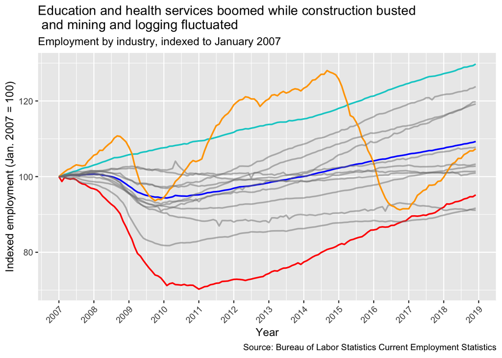

```r
industry_colors <- c("Education and health services" = "cyan3",
                     "Mining and logging" = "orange",
                     "Construction" = "red",
                     "All industries" = "blue",
                     "Other industries" = "gray50")

# TO DO: directly label the industries

# plot indexed employment in selected industries
ggplot(index_naics2, aes(x = date, y = index_jobs * 100, group = industry_name,
                          color = selected_industry, alpha = selected)) +
  geom_path(size = 0.75) +
  scale_color_manual(values = industry_colors, name = "Industry") +
  scale_alpha(range = c(0.5, 1), guide = "none") +
  scale_x_date(date_breaks = "1 year", date_labels = "%Y",
               limits = c(min(index_naics2$date), max(index_naics2$date))) +
  theme(axis.text.x = element_text(angle = 45, hjust = 1),
        legend.position = "none") +
  labs(title = "Education and health services boomed while construction busted \n and mining and logging fluctuated",
       subtitle = "Employment by industry, indexed to January 2007",
       x = "Year", y = "Indexed employment (Jan. 2007 = 100)",
       caption = "Source: Bureau of Labor Statistics Current Employment Statistics")
```

#### Which industries have grown the fastest since the recession?

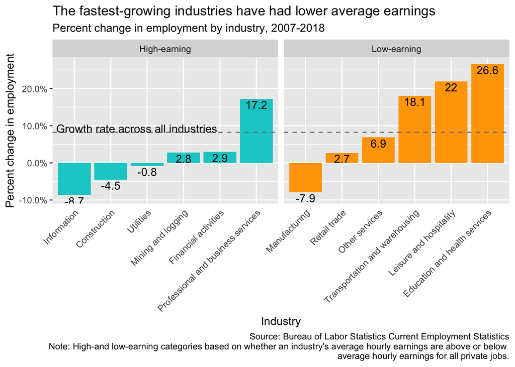

```r
# TO DO: get the x-axis labels to wrap; think about whether to encode industry size

ggplot(filter(industry_growth, !is.na(industry_code)),
       aes(x = reorder(industry_name, pct_change), y = pct_change,
                            fill = earncat)) +
  geom_col() +
  scale_fill_manual(values = c("cyan3", "orange")) +
  geom_text(aes(label = round(pct_change * 100, 1)), hjust = 0.5,
            vjust = 1, nudge_y = -0.005) +
  scale_y_continuous(labels = scales::percent) +
  facet_grid(cols = vars(earncat), scales = "free", space = "free") +
  geom_hline(aes(yintercept = nonfarm_growth), color = "gray50",
             linetype = "dashed") +
  geom_text(data = ann_text, label = "Growth rate across all industries",
            hjust = "left", nudge_x = -0.5) +
  labs(title = "The fastest-growing industries have had lower average earnings",
       subtitle = "Percent change in employment by industry, 2007-2018",
       x = "Industry", y = "Percent change in employment",
       caption = "Source: Bureau of Labor Statistics Current Employment Statistics
       Note: High-and low-earning categories based on whether an industry's average hourly earnings are above or below \n average hourly earnings for all private jobs.")+
  theme(axis.text.x = element_text(angle = 45, hjust = 1),
        axis.ticks.x = element_blank(), legend.position = "none")
```